# Summary Stats on the New Data Dump: Mark II

2017-06-07

Let’s do some quick summary stats on the new data dump, after removing the duplicates I discovered - see `5_31_sum_stats.Rmd`.

```r
knitr::opts_chunk$set(echo = TRUE)
library(readr)
library(dplyr)
library(ggplot2)
library(ggTimeSeries)
library(lubridate)
library(geosphere)
library(viridis)
library(stringr)
library(lme4)
raw_locations <- read_rds('../data/raw/Michigan_DB_user_location_05_31_17.rds')
cleaned_locations <- read_rds('../data/processed/Michigan_DB_user_location_05_31_17_cleaned.rds')
std_locations <- read_rds('../data/processed/std_locations.rds')
twin_distances <- read_rds('../data/processed/twin_distances.rds')
id_mapping <- read_csv('../data/processed/id_mapping_long.csv', col_types = 'ccc')
user_data <- read_rds('../data/raw/Michigan_DB_users_05_31_17.rds')
cleaned_twin_locations <- inner_join(cleaned_locations, id_mapping, by = c("user_id" = "alternate_id")) %>% left_join(user_data, c("user_id" = "alternate_id"))
tweets <- read_rds('../data/raw/Michigan_DB_user_tweet_05_31_17.rds') %>% mutate(tweet_id = as.character(tweet_id))
checkin <- read_rds('../data/processed/remote_substance_use.rds') %>% inner_join(id_mapping, by = c('user_id' = 'alternate_id'))
twin_info <- read_rds('../data/raw/Robin_paper-entry_2-22-17.rds')
par_mon <- read_rds('../data/processed/remote_parents.rds')
comma <- function(x) format(x, digits = 2, big.mark = ",")
```

# Location

In the row data, we have 14,454,058 points in the current data dump. After deduplicating, filtering out observations with missing fields, sample_time values outside of the appropriate ranges, points with an accuracy greater than or equal to 500 meters, and points that don’t correspond to a twin, we have 4,027,683 on 618 individuals. Of those individuals, 73.9705882% have an iPhone, 23.0882353% have an Android phone, and 2.9411765% do not have a recorded device type.

Let’s visualize the distribution of the number of points per twin.

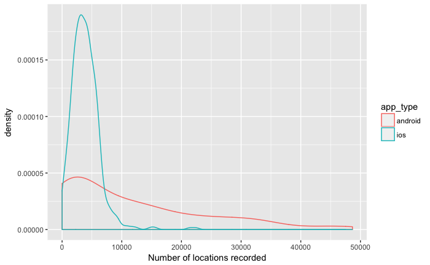

```r
cleaned_twin_locations %>% group_by(user_id) %>% summarize(n = n()) %>% filter(n < 50000) %>% left_join(user_data, by = c("user_id" = "alternate_id")) %>% ggplot(aes(x = n, color = app_type)) + geom_density() + xlab("Number of locations recorded")
```

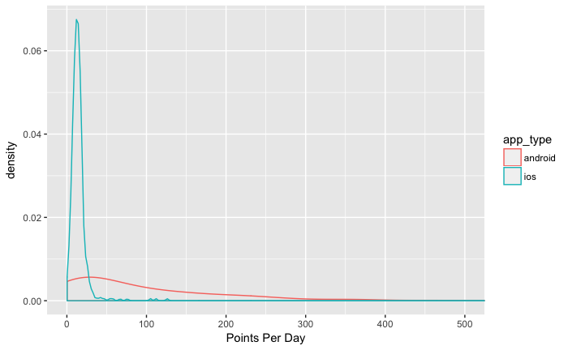

```r
first_last_locs <- cleaned_twin_locations %>% group_by(user_id) %>% summarize(first_point = min(sample_time), last_point = max(sample_time)) %>% mutate(duration_days = as.numeric(last_point - first_point)/60/60/24)
cleaned_twin_locations %>% group_by(user_id) %>% summarize(n = n()) %>% left_join(user_data, by = c("user_id" = "alternate_id")) %>% left_join(first_last_locs) %>% mutate(loc_density = n / duration_days) %>% ggplot(aes(x = loc_density, color = app_type)) + geom_density() + xlab('Points Per Day') + coord_cartesian(xlim = c(0, 500))
```

Now let’s look at the distribution of time between points.

```r
results <- tibble()
for (twin in unique(cleaned_twin_locations$user_id)) {
  results2 <- cleaned_twin_locations %>% filter(user_id == twin) %>% arrange(sample_time) %>% transmute(point_interval = lead(sample_time) - sample_time, app_type = app_type)
  results <- bind_rows(results, results2)
}
```

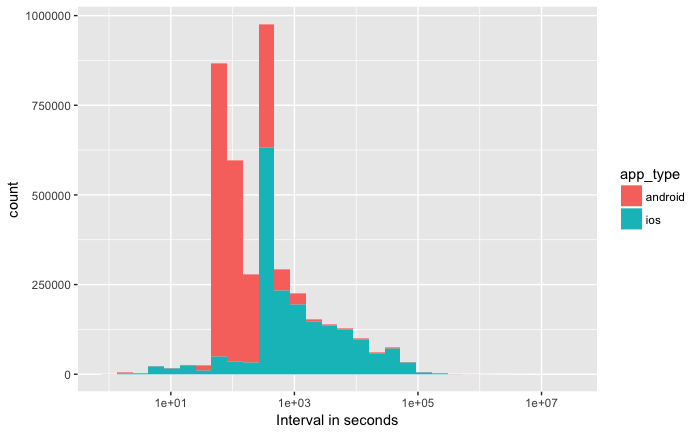

```r
results %>% mutate(point_interval = point_interval + 1) %>% ggplot(aes(x = point_interval, fill = app_type)) + geom_histogram() + scale_x_log10() + xlab('Interval in seconds')
```

Let’s try looking at physical distance between points.

```r
results <- tibble()
for (twin in unique(cleaned_twin_locations$user_id)) {
  results2 <- cleaned_twin_locations %>% filter(user_id == twin) %>% arrange(sample_time) %>% transmute(point_interval = distHaversine(cbind(lead(.$longitude), lead(.$latitude)), cbind(.$longitude, .$latitude)), app_type = app_type)
  results <- bind_rows(results, results2)
}
```

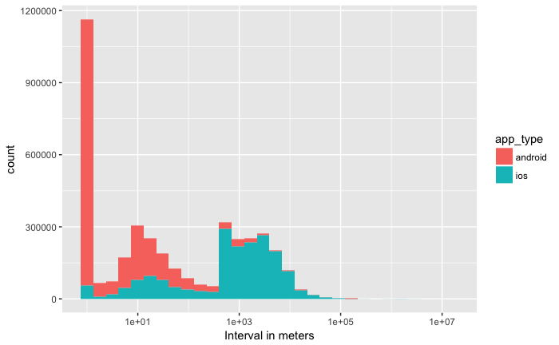

```r
results %>% mutate(point_interval = point_interval + 1) %>% ggplot(aes(x = point_interval, fill = app_type)) + geom_histogram() + scale_x_log10() + xlab('Interval in meters')
```

Let’s look at how many points we’ve received over time.

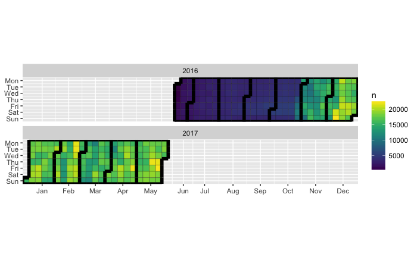

```r
cleaned_twin_locations %>% mutate(date = as.Date(sample_time)) %>% group_by(date) %>% summarize(n = n()) %>% ggplot_calendar_heatmap('date', 'n') + xlab(NULL) + ylab(NULL) + scale_fill_viridis() + facet_wrap(~Year, ncol = 1)
```

What device types have these points come from?

```r
cleaned_twin_locations %>% group_by(app_type) %>% summarize(n = n())
```

| app_type | n |
| --- | --- |
| android | 2093876 |
| ios | 1933807 |

# Tweets

We haven’t received tweet data since April 11. Bizarrely, the user ID is sometimes the hashed Colorado ID and sometimes the Michigan ID. Nevertheless, we have 73,304 tweets from 79 ID’s. 35,313 are retweets.

# Checking In Survey

The “Checking In” substance use survey has been completed 26,153 times by 658 twins. The distribution of number of completed surveys looks like this:

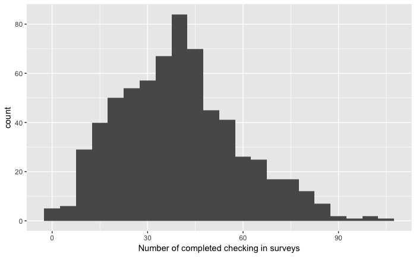

```r
checkin %>% group_by(user_id) %>% summarise(n = n()) %>% ggplot(aes(x = n)) + geom_histogram(binwidth = 5) + xlab('Number of completed checking in surveys')
```

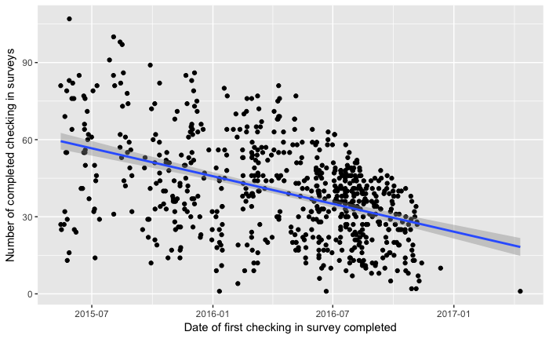

```r
checkin %>% group_by(user_id) %>% summarise(n = n(), first = min(date_completed)) %>% ggplot(aes(x = first, y = n)) + geom_point() + geom_smooth(method = "lm") + xlab("Date of first checking in survey completed") + ylab("Number of completed checking in surveys")
```

In what proportion of weeks do twins use substances?

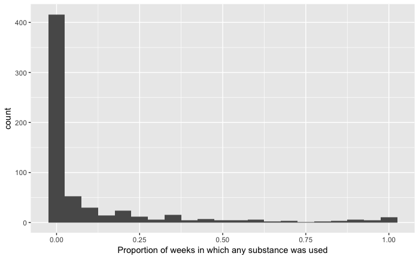

```r
checkin %>% group_by(user_id) %>% summarize(use_prop = sum(any_substance_use) / n()) %>% ggplot(aes(x = use_prop)) + geom_histogram(binwidth = 0.05) + xlab("Proportion of weeks in which any substance was used")
```

# Parental Monitoring Survey

The parental monitoring survey has been completed 3,532 times by 655 twins. The distribution of completed surveys looks like this.

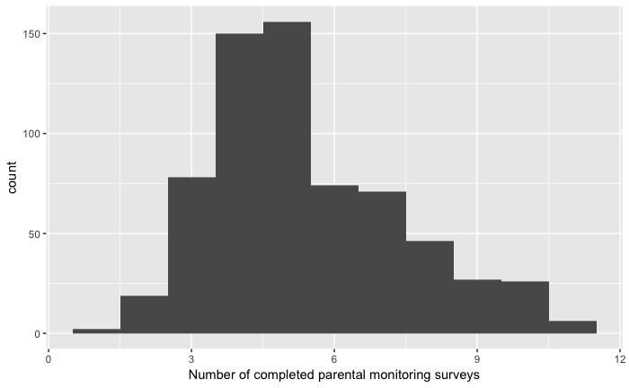

```r
par_mon %>% group_by(user_id) %>% summarise(n = n()) %>% ggplot(aes(x = n)) + geom_histogram(binwidth = 1) + xlab('Number of completed parental monitoring surveys')
```

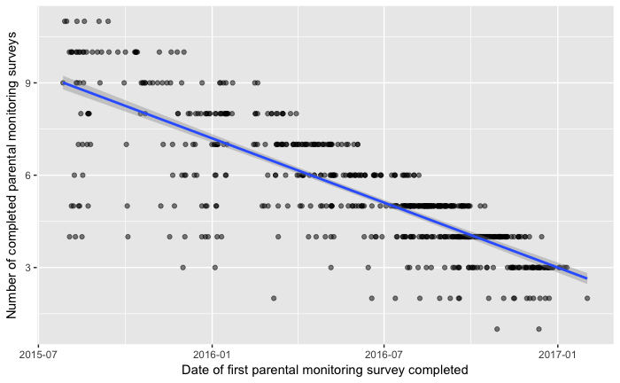

```r
par_mon %>% group_by(user_id) %>% summarise(n = n(), first = min(date_completed)) %>% ggplot(aes(x = first, y = n)) + geom_point(alpha = 0.5) + geom_smooth(method = "lm") + xlab("Date of first parental monitoring survey completed") + ylab("Number of completed parental monitoring surveys")
```

Let’s look at the trajectories of parental monitoring score over the study for each twin.

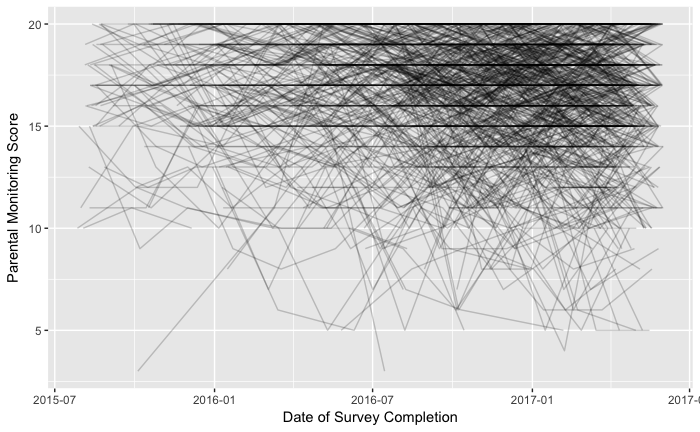

```r
par_mon %>% ggplot(aes(x = date_completed, y = max_monitor_score, group = user_id)) + geom_line(alpha = 0.2) + xlab("Date of Survey Completion") + ylab("Parental Monitoring Score")
```

We can see that there is a tendency to persist at the current level or to shift to a closer level over a further level but that there is significant variation.

# Model of Substance Use and Parental Monitoring

```r
data <- left_join(checkin, twin_info, by = c("SVID" = "ID1"))
data2 <- tibble()
for (twin in unique(data$user_id)) {
  t_data <- data[data$user_id == twin,]
  d   <- function(x,y) abs(x-y) # define the distance function
  idx <- sapply(t_data$date_completed, function(x) which.min( d(x,par_mon$date_completed) )) # find matches
  t_data <- cbind(t_data,par_mon[unlist(idx),-1,drop=FALSE])
  data2 <- bind_rows(data2, t_data)
}
```

Looking first at the longitudinal remote data.

```r
m1 <- glmer(any_substance_use ~ Test_AgeYears + Sex1 + bestzygos.x + max_monitor_score + (1 | family/user_id), data = data2, family = binomial())
summary(m1)
```

```
Generalized linear mixed model fit by maximum likelihood (Laplace
  Approximation) [glmerMod]
 Family: binomial  ( logit )
Formula:
any_substance_use ~ Test_AgeYears + Sex1 + bestzygos.x + max_monitor_score +
    (1 | family/user_id)
   Data: data2

     AIC      BIC   logLik deviance df.resid
  9172.0   9237.2  -4578.0   9156.0    25396

Scaled residuals:
    Min      1Q  Median      3Q     Max
-5.3650 -0.1661 -0.0478 -0.0229  9.5294

Random effects:
 Groups         Name        Variance Std.Dev.
 user_id:family (Intercept) 4.456    2.111
 family         (Intercept) 8.254    2.873
Number of obs: 25404, groups:  user_id:family, 658; family, 330

Fixed effects:
                    Estimate Std. Error z value Pr(>|z|)
(Intercept)       -26.706834   3.149658  -8.479  < 2e-16 ***
Test_AgeYears       1.412698   0.195783   7.216 5.37e-13 ***
Sex1               -0.351717   0.334174  -1.052    0.293
bestzygos.xMZ      -0.351955   0.410743  -0.857    0.392
bestzygos.xOS       0.320963   0.451547   0.711    0.477
max_monitor_score  -0.010544   0.009381  -1.124    0.261
---
Signif. codes:  0 ‘***’ 0.001 ‘**’ 0.01 ‘*’ 0.05 ‘.’ 0.1 ‘ ’ 1

Correlation of Fixed Effects:
            (Intr) Tst_AY Sex1   bst.MZ bst.OS
Test_AgeYrs -0.982
Sex1        -0.123 -0.026
bstzygs.xMZ -0.006 -0.057  0.020
bstzygs.xOS -0.134  0.080 -0.011  0.395
mx_mntr_scr -0.053  0.003  0.001  0.004  0.002
```

Now the in person data

```r
in_person_parent <- read_rds("../data/processed/in_person_parents.rds")
in_person_drug <- read_rds("../data/processed/PhenX_diagnoses.rds")
in_person_drug <- left_join(in_person_drug, in_person_parent, by = "SVID")
in_person_drug <- left_join(in_person_drug, twin_info, by = c("SVID" = "ID1"))
m2 <- glmer(total_drugs_lifetime_use ~ Test_AgeYears + Sex1 + bestzygos + max_monitor_score + (1 | family), data = in_person_drug)
```

```
calling glmer() with family=gaussian (identity link) as a shortcut to lmer() is deprecated; please call lmer() directly
```

```r
summary(m2)
```

```
Linear mixed model fit by REML ['lmerMod']
Formula: total_drugs_lifetime_use ~ Test_AgeYears + Sex1 + bestzygos +
    max_monitor_score + (1 | family)
   Data: in_person_drug

REML criterion at convergence: 1321.7

Scaled residuals:
    Min      1Q  Median      3Q     Max
-3.3980 -0.4577 -0.1220  0.2673  5.1393

Random effects:
 Groups   Name        Variance Std.Dev.
 family   (Intercept) 0.4350   0.6596
 Residual             0.5563   0.7458
Number of obs: 476, groups:  family, 282

Fixed effects:
                  Estimate Std. Error t value
(Intercept)       -0.64358    0.86829  -0.741
Test_AgeYears      0.25873    0.04908   5.271
Sex1              -0.04842    0.09561  -0.506
bestzygosMZ       -0.23078    0.12402  -1.861
bestzygosOS       -0.17441    0.13282  -1.313
max_monitor_score -0.11394    0.01415  -8.054

Correlation of Fixed Effects:
            (Intr) Tst_AY Sex1   bstzMZ bstzOS
Test_AgeYrs -0.912
Sex1        -0.164 -0.045
bestzygosMZ -0.023 -0.065  0.113
bestzygosOS -0.127  0.074  0.045  0.416
mx_mntr_scr -0.439  0.083  0.113 -0.004 -0.018
```

Although it seems like the total lifetime drugs used should be a count distribution, a Poisson-based model fails to converge. This may reflect the zero-inflated nature of the data.

```r
m3 <- glm(any_substance_use ~ Test_AgeYears + Sex1 + bestzygos.x + max_monitor_score, data = data2, family = binomial(link = "logit"))
summary(m3)
```

```
Call:
glm(formula = any_substance_use ~ Test_AgeYears + Sex1 + bestzygos.x +
    max_monitor_score, family = binomial(link = "logit"), data = data2)

Deviance Residuals:
    Min       1Q   Median       3Q      Max
-0.7437  -0.5195  -0.4178  -0.3351   2.6065

Coefficients:
                   Estimate Std. Error z value Pr(>|z|)
(Intercept)       -8.744340   0.351258 -24.894  < 2e-16 ***
Test_AgeYears      0.456620   0.020748  22.008  < 2e-16 ***
Sex1              -0.103493   0.044094  -2.347  0.01892 *
bestzygos.xMZ     -0.278896   0.048301  -5.774 7.74e-09 ***
bestzygos.xOS     -0.413790   0.056730  -7.294 3.01e-13 ***
max_monitor_score -0.019526   0.006848  -2.851  0.00435 **
---
Signif. codes:  0 ‘***’ 0.001 ‘**’ 0.01 ‘*’ 0.05 ‘.’ 0.1 ‘ ’ 1

(Dispersion parameter for binomial family taken to be 1)

    Null deviance: 16405  on 25403  degrees of freedom
Residual deviance: 15808  on 25398  degrees of freedom
  (749 observations deleted due to missingness)
AIC: 15820

Number of Fisher Scoring iterations: 5
```

What can we conclude here? When we use a mixed effects model with random intercepts, nested by individuals within families in the longitudinal case or by family alone in the in person case, the variability of parental monitoring within a family and individual over time is not predictive of the use of drugs in any given week but parental monitoring is predictive of the total number of drugs used in a lifetime in the in person data. If we do simple logistic regression on the longitudinal data, the parental monitoring score is predictive of whether an individual used a substance or not in a given week. One possible interpretation is that the fluctuation of parental monitoring over time for a pair of twins or for an individual twin does not affect their substance use - at least at the time scales we’re looking at. But baseline parental monitoring does affect substance use. Unresolved questions - why does zygosity have significant predictive value in the last model? Are these models fit appropriately?